# Portfolio 10

Cynthia Jiao

2025-04-25

Hi Mason, this data is from another project I am doing with Katharine. We wondered if some cues could help children better recognize a peer exclusion based on race in the hypothetical scenes. We examined the effect of labeling race for children, exclusion marking, and switching between okay/not okay or like/not like question types on children’s evaluation and confrontation of racial discrimination. I just got the most of the full data (still missing a few but they probably wouldn’t sway the results too much) and this portfolio is to examine the effect of all 3 IVs on children’s evaluation of racial discrimination, since we need RA’s coding to measure children’s confrontation. All 3 IVs are categorical (2 levels within each IV). DV (evaluation) is continous from -6 to 6.

## Preregistered Analyses

1. Is there an effect of labeling, exclusion marking, or like/okay question type on children’s evaluation of discrimination?

Labeling race has a significant effect on children’s evaluation of discrimination such that children in labeling condition are more likely to negatively evaluate the discrimination. β = –1.79, SE = 0.58, t = –3.08, p = .002.

Exclusion marking has a significant effect on children’s evaluation of discrimination such that children in exclusion marking condition are more likely to negatively evaluate the discrimination. β = –1.40, SE = 0.58, t = –2.42, p = .02

Question type has a significant effect on children’s evaluation of discrimination such that children who are asked “do you think this is okay or not okay” are more likely to negatively evaluate the discrimination. β = –1.24, SE = 0.58, t = –2.14, p = .03

I don’t have a lot of thoughts on why there is no interaction between any of the IVs at all, since I didn’t have a specific prediction for possible interactions, but I will dig more into this after I have the full sample size with all variables…

```
##
## Call:
## lm(formula = evaluation ~ LabelingC * ExclusionC * LikeOkayC,
##     data = morki2)
##
## Residuals:
##     Min      1Q  Median      3Q     Max
## -7.7500 -2.9130 -0.1818  3.2500  7.6429
##
## Coefficients:
##                                Estimate Std. Error t value Pr(>|t|)
## (Intercept)                      0.4841     0.2898   1.670  0.09659 .
## LabelingC                       -1.7857     0.5797  -3.081  0.00239 **
## ExclusionC                      -1.4031     0.5797  -2.421  0.01649 *
## LikeOkayC                       -1.2408     0.5797  -2.141  0.03366 *
## LabelingC:ExclusionC            -0.4809     1.1593  -0.415  0.67878
## LabelingC:LikeOkayC             -1.2562     1.1593  -1.084  0.28002
## ExclusionC:LikeOkayC             0.8482     1.1593   0.732  0.46536
## LabelingC:ExclusionC:LikeOkayC   2.4804     2.3186   1.070  0.28616
## ---
## Signif. codes:  0 '***' 0.001 '**' 0.01 '*' 0.05 '.' 0.1 ' ' 1
##
## Residual standard error: 3.948 on 179 degrees of freedom
##   (2 observations deleted due to missingness)
## Multiple R-squared:  0.1194, Adjusted R-squared:  0.08496
## F-statistic: 3.467 on 7 and 179 DF,  p-value: 0.001655
```

```
##                                      2.5 %      97.5 %
## (Intercept)                    -0.08778895  1.05604371
## LabelingC                      -2.92956342 -0.64189809
## ExclusionC                     -2.54695472 -0.25928940
## LikeOkayC                      -2.38460294 -0.09693762
## LabelingC:ExclusionC           -2.76854712  1.80678353
## LabelingC:LikeOkayC            -3.54384357  1.03148708
## ExclusionC:LikeOkayC           -1.43949574  3.13583491
## LabelingC:ExclusionC:LikeOkayC -2.09493351  7.05572779
```

2. Is there an effect of labeling, exclusion marking, or like/okay question type on children’s confrontation of discrimination?

I don’t have data for this analysis yet, but I wrote the codes any ways! Children’s confrontation (DV) is a categorical variable with two levels, so we are using generalized linear model, not lm.

## Graph the Effects

1. main effect of 3 IVs on children’s evaluation, separately, since there is not any interaction effect.

```
## NOTE: Results may be misleading due to involvement in interactions
## NOTE: Results may be misleading due to involvement in interactions
## NOTE: Results may be misleading due to involvement in interactions
```

# bar graph for race labeling on evaluation

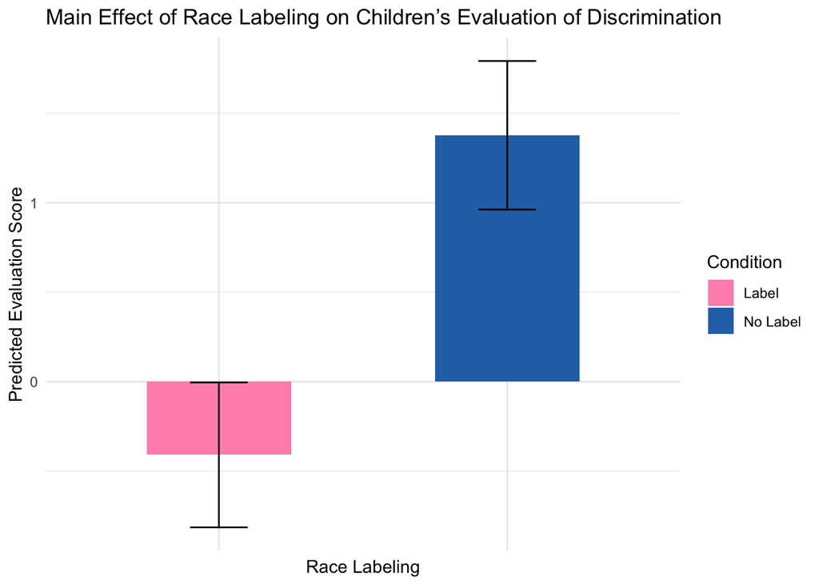

# bar graph for question type on evaluation

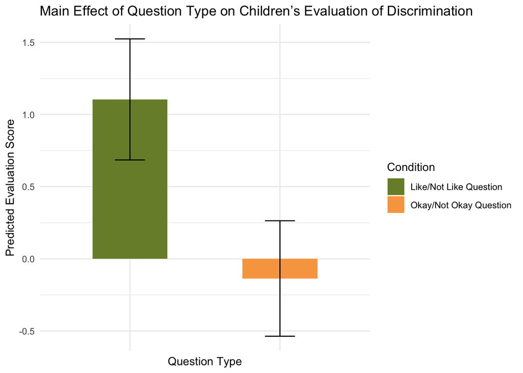

# bar graph for exclusion marking on evaluation

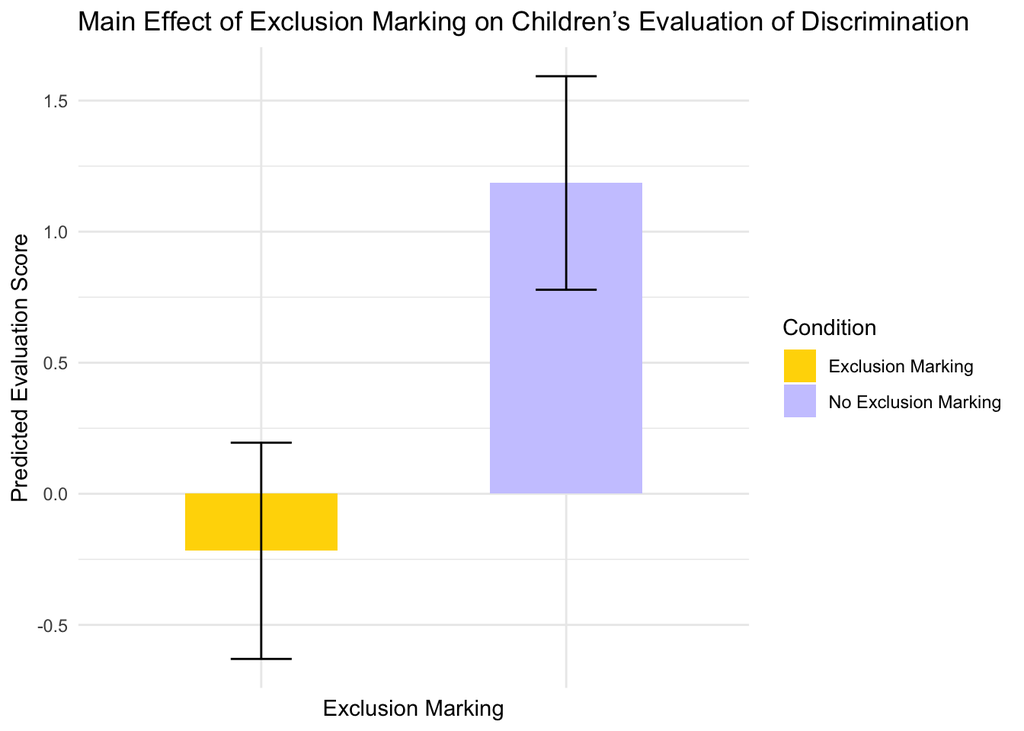